# Deserialization of Objects to a Workspace

# $\Lambda_c^+ \to p K^- \pi^+$

Model definition: [`lc2ppik-lhcb-2683025.json`](https://github.com/RUB-EP1/amplitude-serialization/blob/main/models/lc2ppik-lhcb-2683025.json).

This page demonstrates deserialization and evaluation of an amplitude model for the decay $\Lambda_c^+ \to p K^- \pi^+$. The amplitude analysis is performed based on roughly half a million of $\Lambda_c^{\pm}$ decay candidates by the LHCb collaboration, [INSPIRE-HEP 2683025](https://inspirehep.net/literature/2683025). Details on the mapped of the amplitude model onto the standard helicity formalism can be found in appendix of [INSPIRE-HEP 2623821](https://inspirehep.net/literature/2623821).

**Activate environment**

```julia
import Pkg
Pkg.activate(@__DIR__)
Pkg.instantiate()

using ThreeBodyDecaysIO
using ThreeBodyDecaysIO.ThreeBodyDecays
using ThreeBodyDecaysIO.HadronicLineshapes
using ThreeBodyDecaysIO.Parameters
using ThreeBodyDecaysIO.DataFrames
using ThreeBodyDecaysIO.JSON
using Measurements
using Statistics
using QuadGK
using Plots

theme(:wong2, frame=:box, grid=false, minorticks=true,
    guidefontvalign=:top, guidefonthalign=:right,
    foreground_color_legend=nothing,
    xlim=(:auto, :auto), ylim=(:auto, :auto),
    lab="")
```

Model components are deserialized from a JSON file into computational objects within a workspace for further manipulation. First, functions representing lineshapes and form factors are built. Following this, distributions are processed and added to the workspace.

```julia
input = open(joinpath(@__DIR__, "..", "..", "models", "lc2ppik-lhcb-2683025.json")) do io
    JSON.parse(io)
end

workspace = Dict{String,Any}()

@unpack functions = input
for fn in functions
    @unpack name, type = fn
    instance_type = eval(Symbol(type))
    workspace[name] = dict2instance(instance_type, fn)
end

@unpack distributions = input
for dist in distributions
    @unpack name, type = dist
    instance_type = eval(Symbol(type))
    workspace[name] = dict2instance(instance_type, distributions[1]; workspace)
end
```

```
┌ Warning: parameters are not used in HadronicUnpolarizedIntensity

└ @ ThreeBodyDecaysIO ~/.julia/packages/ThreeBodyDecaysIO/g3kTv/src/HadronicUnpolarizedIntensity.jl:19
```

## Validation

The integrity of the model is checked by validating the value of distributions at a few phase space points. The table lists the validation checks and their status. The marks “🟢”, “🟡”, and “🔴” indicate an accuracy of $<10^{-10}$, $<10^{-2}$, or $\ge10^{-2}$, respectively, for the difference between the reference and computed values.

**A loop over validation points**

```julia
let
    @unpack misc, parameter_points = input
    @unpack amplitude_model_checksums = misc

    map(amplitude_model_checksums) do check_point_info
        @unpack point, value, distribution = check_point_info
        #
        # pull distribution
        dist = workspace[distribution]

        # pull correct parameter point
        parameter_points_dict = array2dict(parameter_points; key="name")
        # find the point in the list of points
        parameter_point = parameter_points_dict[point]
        # compute, compare
        _parameters = array2dict(parameter_point["parameters"];
            key="name", apply=v -> v["value"])
        #
        computed_value = dist(_parameters)
        #
        tonumber(X::Number) = X
        tonumber(X::String) = string2complex(X)
        reference_value = tonumber(value)
        status = label_diff(reference_value - computed_value; levels=[1e-2, 1e-10])
        #
        (; Distribution=distribution,
            Point=point, Status=status)
    end |> DataFrame
end
```

11×3 DataFrame

| Row | Distribution String | Point String | Status Char |
| --- | --- | --- | --- |
| 1 | default_model | validation_point | 🟢 |
| 2 | L1405_Flatte | validation_point_m31sq | 🟢 |
| 3 | L1690_BW | validation_point_m31sq | 🟢 |
| 4 | D1232_BW | validation_point_m12sq | 🟢 |
| 5 | L1520_BW | validation_point_m31sq | 🟢 |
| 6 | L1600_BW | validation_point_m31sq | 🟢 |
| 7 | L2000_BW | validation_point_m31sq | 🟢 |
| 8 | D1600_BW | validation_point_m12sq | 🟢 |
| 9 | D1700_BW | validation_point_m12sq | 🟢 |
| 10 | K892_BW | validation_point_m23sq | 🟢 |
| 11 | L1670_BW | validation_point_m31sq | 🟢 |

## Visualization

The model describing the decay is fetched from the workspace

```julia
model_dist = [v for (k, v) in workspace if v isa HadronicUnpolarizedIntensity] |> first;
```

### Dalitz plot

The Dalitz plot shows the probability distribution across two dimensional phase space of the decay.

**Dalitz plot plotting**

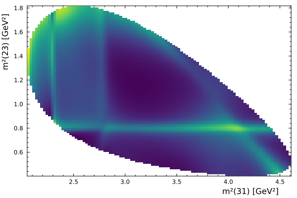

```julia
let iσx = 2, iσy = 1
    xlab = ((i, j) = ij_from_k(iσx);
    "m²($i$j) [GeV²]")
    ylab = ((i, j) = ij_from_k(iσy);
    "m²($i$j) [GeV²]")
    model = model_dist.model

    plot(masses(model), Base.Fix1(unpolarized_intensity, model);
        iσx, iσy, xlab, ylab)
end
```

The projection of the model onto a mass variable is shown by black line. Contributions from individual resonances are shown by the colored lines.

**Computation of projections**

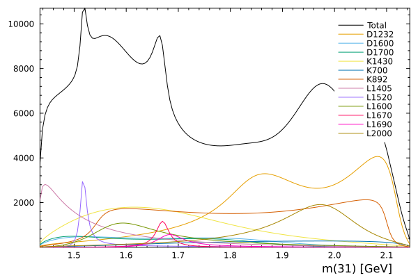

```julia
let k = 2
    i, j = ij_from_k(k)
    xlab = "m($i$j) [GeV]"
    model = model_dist.model
    #
    mlims = sqrt.(lims(k, masses(model)))
    mv = range(mlims..., 150) |> shift_by_half
    #
    plot()
    plot!(mv, lab="Total") do m
        I = Base.Fix1(unpolarized_intensity, model)
        m * quadgk(projection_integrand(I, masses(model), m^2; k), 0, 1)[1]
    end
    chain_names = Set(model.names) |> collect |> sort
    for name in chain_names
        _model = model[model.names.==name]
        plot!(mv, lab=name) do m
            I = Base.Fix1(unpolarized_intensity, _model)
            m * quadgk(projection_integrand(I, masses(_model), m^2; k), 0, 1)[1]
        end
    end
    plot!(; xlab)
end
```

## Fit Fractions

The contribution of different resonances to the overall decay process is quantitatively assessed using numerical evaluation on a finite-size sample. Statistical uncertainty in the reported values only reflects the precision of these calculations. For a understanding of model uncertainties, refer to the original publications.

**Computation of fit fractions**

```julia
let
    model = model_dist.model
    ms = masses(model)
    #
    x2 = rand(10000, 2)
    data = map(eachslice(x2; dims=1)) do (x, y)
        σ1 = lims1(ms)[1] + x * diff(lims1(ms) |> collect)[1]
        σ2 = lims2(ms)[1] + y * diff(lims2(ms) |> collect)[1]
        σs = Invariants(ms; σ1, σ2)
    end
    filter!(data) do σs
        Kibble(σs, ms^2) < 0
    end
    #
    chain_names = Set(model.names) |> collect |> sort
    _int_i = map(chain_names) do name
        _intensities = unpolarized_intensity.(model[model.names.==name] |> Ref, data)
        _value = mean(_intensities)
        _err = sqrt(cov(_intensities, _intensities) / length(data))
        _value ± _err
    end
    _int0 = sum(unpolarized_intensity.(model |> Ref, data)) / length(data)
    ff = round.(_int_i ./ _int0 .* 100; digits=2)
    DataFrame("Resonance" => chain_names, "Fit Fraction [%]" => ff)
end
```

12×2 DataFrame

| Row | Resonance String | Fit Fraction [%] Measurem… |
| --- | --- | --- |
| 1 | D1232 | 28.08±0.57 |
| 2 | D1600 | 4.53±0.06 |
| 3 | D1700 | 3.92±0.06 |
| 4 | K1430 | 14.76±0.22 |
| 5 | K700 | 3.01±0.04 |
| 6 | K892 | 21.4±0.52 |
| 7 | L1405 | 7.94±0.21 |
| 8 | L1520 | 1.96±0.09 |
| 9 | L1600 | 5.2±0.06 |
| 10 | L1670 | 1.16±0.03 |
| 11 | L1690 | 1.18±0.03 |
| 12 | L2000 | 9.71±0.12 |